# Partial Replication Data for Jena and Olenski (2018)

David Kane

March 22, 2018

Purpose of this document is to provide a tour of some of the data associated with Jena and Olenski (2018).[^1]

```r
x <- read_csv("yearly.csv")
x$year <- as.factor(x$year)
x$convention <- ifelse(x$date == 0, TRUE, FALSE)
x$rate <- (100000 * x$gunshot)/x$total
```

With this raw data, we can calculate the total firearm injuries and hospital visits and then, with those totals, calculate a rate per 100,000, as in the article.

```r
x %>% group_by(convention) %>%
  summarize(gunshots = sum(gunshot), totals = sum(total)) %>%
  mutate(total_rate = 100000 * gunshots/totals) -> y
```

We can also look at the data by the seven individual weeks surrounding the convention, thereby producing a graphic not dissimilar to their Figure 1 (B) and a close match to their Figure S1.

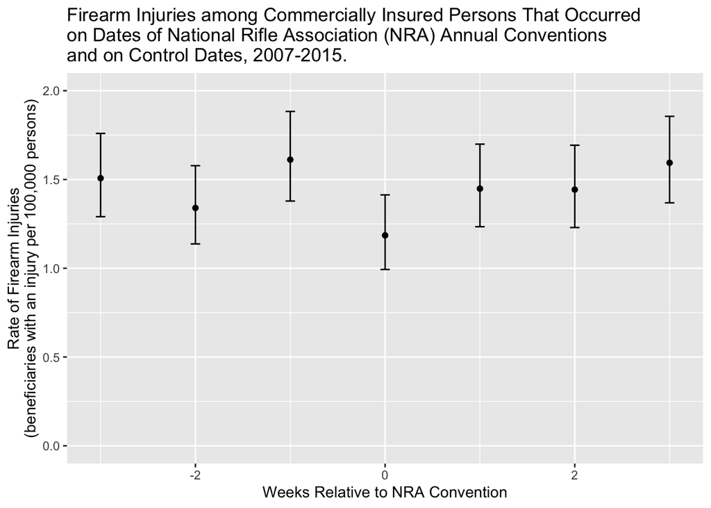

I prefer to look at the data for each year-by-date combination separately. We have 9 unique years from 2007 through 2015. We have 7 dates for each year, the convention week (date 0) and the three weeks before and the three weeks after. So, we have 63 observations. Let’s examine the rate of firearm injuries per 100,000 hospital visits for each year-by-date.

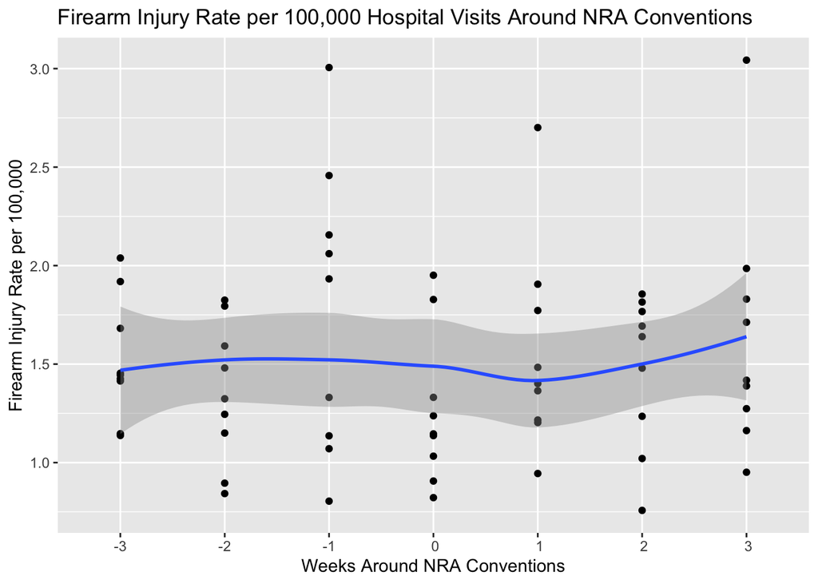

Whether or not smoothing the observations makes sense depends on your priors about the relationships among injury rates over time.

## Differences Between Convention Weeks and Other Weeks

Is the difference between the rate of gunshot injuries during NRA conventions different from the rate in the three weeks before and after the convention?[^4] I *think* this depends on how we ask the question. We have 9 observations for convention weeks and 54 observations for non-convention weeks. Define the firearm injury rate per 100,000 as the number of gunshot injuries divided by the total number of hospital visits, all multiplied by 100,000. A simple t-test produces:

```r
t.test(x$rate[x$convention == 0], x$rate[x$convention != 0])
```

```
##
##  Welch Two Sample t-test
##
## data:  x$rate[x$convention == 0] and x$rate[x$convention != 0]
## t = 1.9542, df = 12.977, p-value = 0.07257
## alternative hypothesis: true difference in means is not equal to 0
## 95 percent confidence interval:
##  -0.03021299  0.60185484
## sample estimates:
## mean of x mean of y
##  1.551570  1.265749
```

If we assume that we have 63 individual observations, then the difference between the injury rates between NRA convention weeks and non-NRA convention weeks is not statistically significant.

How can the authors report that the difference is significant? Because they do not frame the question in this fashion. Instead, they pool all the injuries and visits during convention weeks and compare that proportion to the total injuries and visits during non-convention weeks.

```r
prop.test(y$gunshots, y$totals)
```

```
##
##  2-sample test for equality of proportions with continuity
##  correction
##
## data:  y$gunshots out of y$totals
## X-squared = 5.7295, df = 1, p-value = 0.01668
## alternative hypothesis: two.sided
## 95 percent confidence interval:
##  7.300024e-07 5.339666e-06
## sample estimates:
##       prop 1       prop 2
## 1.488771e-05 1.185288e-05
```

Note that this confidence interval is close (but does not match exactly) with the one they calculated in the paper. Either way, a proportion test does produce a statistically significant result. It is unclear (to me) which test is more appropriate in this context.

[^1]: Jena AB, Olenski AR. [Reduction in firearm injuries during NRA annual conventions](http://www.nejm.org/doi/full/10.1056/NEJMc1712773). N Engl J Med 2018;378:866-7. DOI: 10.1056/NEJMc1712773. Thanks to Anupam Jena for providing the data and for helpful discussion.
[^2]: I am not sure how this confidence interval is calculated.
[^3]: See related discussion at Andrew Gelman’s [blog](http://andrewgelman.com/2018/03/05/no-dont-believe-reduction-firearm-injuries-nra-annual-conventions-story/).
[^4]: Thanks to Dale Lehman for highlighting this issue.